# What is the correlation between amount spent on advertising and profits gained by four major airlines?

This is an [R Markdown](http://rmarkdown.rstudio.com) Notebook that will explore the possible correlation between the advertising budgets and profits gained by four United States-based airlines. Finding this correlation is extremely useful to airlines to maximize their profit and avoid over-spending.  
After researching which airlines were most frequently used, the names of the airlines were recorded into tables. The tables include the four airlines (American Airlines, Delta Airlines, Southwest Airlines, and United Airlines) and the advertising budgets of each airline for the years found. Each airline’s profits for the ten year span chosen were also turned into a table.

```r
avp1= fread(file.choose(),sep = "," )
avp2= fread(file.choose(),sep = "," )
avp3= fread(file.choose(),sep = "," )
avp4= fread(file.choose(),sep = "," )
advertise = fread(file.choose(), sep = ",")
profit = fread(file.choose(), sep = ",")
```

In addition to viewing the profit and advertisement cost of each airline separately, a fifth table was created to view the average amount spent on advertising among all four airlines as well as the average profit.

```r
aap = fread(file.choose(),sep = ",")
```

After creating tables to view each company’s annual report of their profits and advertising budgets, both variables were plotted over a ten year span as well.

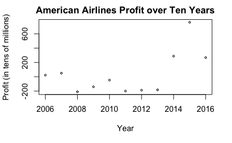

```r
plot(avp1$Year,avp1$Profit, type = "p",cex=.5, main = "American Airlines Profit over Ten Years", xlab ="Year", ylab ="Profit (in tens of millions)" )
```

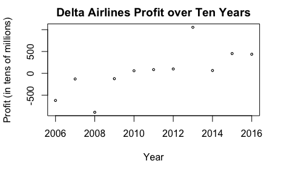

```r
plot(avp2$Year,avp2$Profit, type = "p",cex=.5, main = "Delta Airlines Profit over Ten Years", xlab ="Year", ylab ="Profit (in tens of millions)" )
```

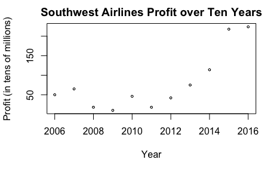

```r
plot(avp3$Year,avp3$Profit, type = "p",cex=.5,main = "Southwest Airlines Profit over Ten Years", xlab ="Year", ylab ="Profit (in tens of millions)" )
```

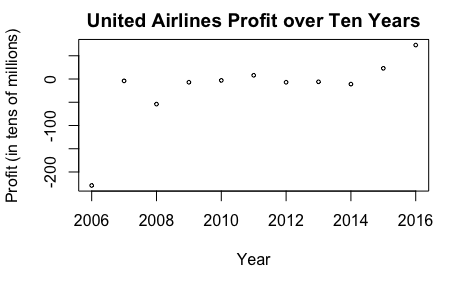

```r
plot(avp4$Year,avp4$Profit, type = "p",cex=.5,main = "United Airlines Profit over Ten Years", xlab ="Year", ylab ="Profit (in tens of millions)" )
```

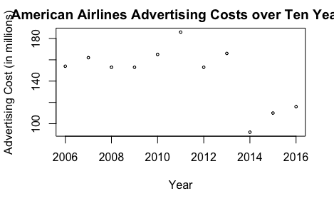

```r
plot(avp1$Year,avp1$Advertising, type = "p",cex=.5, main = "American Airlines Advertising Costs over Ten Years", xlab ="Year", ylab ="Advertising Cost (in millions)" )
```

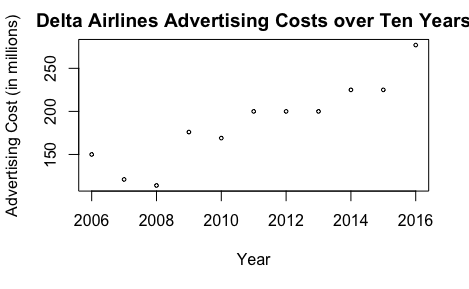

```r
plot(avp2$Year,avp2$Advertising, type = "p",cex=.5, main = "Delta Airlines Advertising Costs over Ten Years", xlab ="Year", ylab ="Advertising Cost (in millions)" )
```

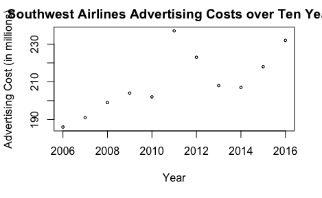

```r
plot(avp3$Year,avp3$Advertising, type = "p",cex=.5,main = "Southwest Airlines Advertising Costs over Ten Years", xlab ="Year", ylab ="Advertising Cost (in millions)" )
```

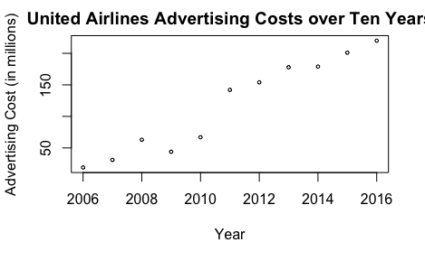

```r
plot(avp4$Year,avp4$Advertising, type = "p",cex=.5,main = "United Airlines Advertising Costs over Ten Years", xlab ="Year", ylab ="Advertising Cost (in millions)" )
```

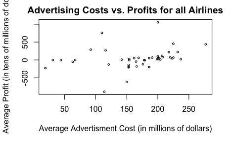

```r
plot(alldata$`Advertising (millions)`,alldata$`Profit (tens of millions)`, type = "p",cex=.5, main = "Advertising Costs vs. Profits for all Airlines", xlab ="Average Advertisment Cost (in millions of dollars)", ylab ="Average Profit (in tens of millions of dollars)" )
```

After plotting both variables for each airline, a linear regression model was created for the advertisement cost vs. the profit of all the airlines in an attempt to prove correlation between advertising budget and profit.

```r
avp1$label = "American"
avp2$label= "Delta"
avp3$label = "Southwest"
avp4$label = "United"
alldata=rbind(avp1, avp2,avp3,avp4)
model2 = lm(alldata$`Profit (tens of millions)`~alldata$`Advertising (millions)`)
summary(model2)
```

```
Call:
lm(formula = alldata$`Profit (tens of millions)` ~ alldata$`Advertising (millions)`)

Residuals:
    Min      1Q  Median      3Q     Max
-857.66  -79.65  -23.28   61.46  970.74

Coefficients:
                                  Estimate Std. Error t value Pr(>|t|)
(Intercept)                      -190.2244   133.4316  -1.426   0.1614
alldata$`Advertising (millions)`    1.3674     0.7629   1.792   0.0803 .
---
Signif. codes:  0 ‘***’ 0.001 ‘**’ 0.01 ‘*’ 0.05 ‘.’ 0.1 ‘ ’ 1

Residual standard error: 289.5 on 42 degrees of freedom
Multiple R-squared:  0.07105,   Adjusted R-squared:  0.04893
F-statistic: 3.212 on 1 and 42 DF,  p-value: 0.08029
```

# Works Cited:

https://skift.com/2016/03/24/the-u-s-set-a-new-record-for-airline-passengers-in-2015/

https://www.statista.com/statistics/308960/southwest-airlines-advertising-spending-usa/

https://www.statista.com/statistics/480867/american-airlines-ad-spend-usa/

https://americanairlines.gcs-web.com/sec-filings?items_per_page=10&order=field_nir_sec_form&sort=asc&page=1

https://www.sec.gov/Archives/edgar/data/4515/000000620114000004/aagaa10k-20131231.htm

http://www.oliverwyman.com/content/dam/oliver-wyman/global/en/2016/jan/oliver-wyman-airline-economic-analysis-2015-2016.pdf

https://www.statista.com/statistics/220809/operating-revenue-of-delta-air-lines/

http://investors.southwest.com/~/media/Files/S/Southwest-IR/documents/company-reports-ar/ar-2006.pdf

http://ir.united.com/financial-performance/sec-filings

http://ir.united.com/financial-performance/sec-filings

http://investors.southwest.com/financials/company-reports/annual-reports

https://americanairlines.gcs-web.com/financial-results/financial-aal